# Risk Factor Analysis

## Outcome Variable

**Outcome Variable:** ever_wasted

## Predictor Variables

**Intervention Variable:** meducyrs

**Adjustment Set:**

- arm
- W_mage
- feducyrs
- W_mhtcm
- W_gagebrth
- W_birthwt
- W_birthlen
- single
- delta_W_mage
- delta_feducyrs
- delta_W_mhtcm
- delta_W_gagebrth
- delta_W_birthwt
- delta_W_birthlen
- delta_single

## Stratifying Variables

The analysis was stratified on these variable(s):

- agecat
- studyid
- country

## Data Summary

| agecat | studyid | country | meducyrs | ever_wasted | n_cell | n |
| --- | --- | --- | --- | --- | --- | --- |
| 0-24 months | ki0047075b-MAL-ED | BANGLADESH | High | 0 | 59 | 213 |
| 0-24 months | ki0047075b-MAL-ED | BANGLADESH | High | 1 | 19 | 213 |
| 0-24 months | ki0047075b-MAL-ED | BANGLADESH | Low | 0 | 46 | 213 |
| 0-24 months | ki0047075b-MAL-ED | BANGLADESH | Low | 1 | 24 | 213 |
| 0-24 months | ki0047075b-MAL-ED | BANGLADESH | Medium | 0 | 44 | 213 |
| 0-24 months | ki0047075b-MAL-ED | BANGLADESH | Medium | 1 | 21 | 213 |
| 0-24 months | ki0047075b-MAL-ED | BRAZIL | High | 0 | 76 | 232 |
| 0-24 months | ki0047075b-MAL-ED | BRAZIL | High | 1 | 3 | 232 |
| 0-24 months | ki0047075b-MAL-ED | BRAZIL | Low | 0 | 55 | 232 |
| 0-24 months | ki0047075b-MAL-ED | BRAZIL | Low | 1 | 8 | 232 |
| 0-24 months | ki0047075b-MAL-ED | BRAZIL | Medium | 0 | 82 | 232 |
| 0-24 months | ki0047075b-MAL-ED | BRAZIL | Medium | 1 | 8 | 232 |
| 0-24 months | ki0047075b-MAL-ED | INDIA | High | 0 | 39 | 220 |
| 0-24 months | ki0047075b-MAL-ED | INDIA | High | 1 | 24 | 220 |
| 0-24 months | ki0047075b-MAL-ED | INDIA | Low | 0 | 33 | 220 |
| 0-24 months | ki0047075b-MAL-ED | INDIA | Low | 1 | 43 | 220 |
| 0-24 months | ki0047075b-MAL-ED | INDIA | Medium | 0 | 44 | 220 |
| 0-24 months | ki0047075b-MAL-ED | INDIA | Medium | 1 | 37 | 220 |
| 0-24 months | ki0047075b-MAL-ED | NEPAL | High | 0 | 40 | 225 |
| 0-24 months | ki0047075b-MAL-ED | NEPAL | High | 1 | 13 | 225 |
| 0-24 months | ki0047075b-MAL-ED | NEPAL | Low | 0 | 69 | 225 |
| 0-24 months | ki0047075b-MAL-ED | NEPAL | Low | 1 | 27 | 225 |
| 0-24 months | ki0047075b-MAL-ED | NEPAL | Medium | 0 | 51 | 225 |
| 0-24 months | ki0047075b-MAL-ED | NEPAL | Medium | 1 | 25 | 225 |
| 0-24 months | ki0047075b-MAL-ED | PERU | High | 0 | 87 | 301 |
| 0-24 months | ki0047075b-MAL-ED | PERU | High | 1 | 3 | 301 |
| 0-24 months | ki0047075b-MAL-ED | PERU | Low | 0 | 93 | 301 |
| 0-24 months | ki0047075b-MAL-ED | PERU | Low | 1 | 11 | 301 |
| 0-24 months | ki0047075b-MAL-ED | PERU | Medium | 0 | 95 | 301 |
| 0-24 months | ki0047075b-MAL-ED | PERU | Medium | 1 | 12 | 301 |

[output cut: 438 more lines]

The following strata were considered:

- agecat: 0-24 months, studyid: ki0047075b-MAL-ED, country: BANGLADESH
- agecat: 0-24 months, studyid: ki0047075b-MAL-ED, country: BRAZIL
- agecat: 0-24 months, studyid: ki0047075b-MAL-ED, country: INDIA
- agecat: 0-24 months, studyid: ki0047075b-MAL-ED, country: NEPAL
- agecat: 0-24 months, studyid: ki0047075b-MAL-ED, country: PERU
- agecat: 0-24 months, studyid: ki0047075b-MAL-ED, country: SOUTH AFRICA
- agecat: 0-24 months, studyid: ki0047075b-MAL-ED, country: TANZANIA, UNITED REPUBLIC OF
- agecat: 0-24 months, studyid: ki1000108-CMC-V-BCS-2002, country: INDIA
- agecat: 0-24 months, studyid: ki1000108-IRC, country: INDIA
- agecat: 0-24 months, studyid: ki1000109-EE, country: PAKISTAN
- agecat: 0-24 months, studyid: ki1000304b-SAS-CompFeed, country: INDIA
- agecat: 0-24 months, studyid: ki1000304b-SAS-FoodSuppl, country: INDIA
- agecat: 0-24 months, studyid: ki1017093-NIH-Birth, country: BANGLADESH
- agecat: 0-24 months, studyid: ki1017093b-PROVIDE, country: BANGLADESH
- agecat: 0-24 months, studyid: ki1017093c-NIH-Crypto, country: BANGLADESH
- agecat: 0-24 months, studyid: ki1066203-TanzaniaChild2, country: TANZANIA, UNITED REPUBLIC OF
- agecat: 0-24 months, studyid: ki1112895-Guatemala BSC, country: GUATEMALA
- agecat: 0-24 months, studyid: ki1113344-GMS-Nepal, country: NEPAL
- agecat: 0-24 months, studyid: ki1119695-PROBIT, country: BELARUS
- agecat: 0-24 months, studyid: ki1126311-ZVITAMBO, country: ZIMBABWE
- agecat: 0-24 months, studyid: ki1135781-COHORTS, country: GUATEMALA
- agecat: 0-24 months, studyid: ki1135781-COHORTS, country: INDIA
- agecat: 0-24 months, studyid: ki1135781-COHORTS, country: PHILIPPINES
- agecat: 0-24 months, studyid: ki1148112-LCNI-5, country: MALAWI
- agecat: 0-24 months, studyid: kiGH5241-JiVitA-3, country: BANGLADESH
- agecat: 0-24 months, studyid: kiGH5241-JiVitA-4, country: BANGLADESH
- agecat: 0-6 months, studyid: ki0047075b-MAL-ED, country: BANGLADESH
- agecat: 0-6 months, studyid: ki0047075b-MAL-ED, country: BRAZIL
- agecat: 0-6 months, studyid: ki0047075b-MAL-ED, country: INDIA
- agecat: 0-6 months, studyid: ki0047075b-MAL-ED, country: NEPAL
- agecat: 0-6 months, studyid: ki0047075b-MAL-ED, country: PERU
- agecat: 0-6 months, studyid: ki0047075b-MAL-ED, country: SOUTH AFRICA
- agecat: 0-6 months, studyid: ki0047075b-MAL-ED, country: TANZANIA, UNITED REPUBLIC OF
- agecat: 0-6 months, studyid: ki1000108-CMC-V-BCS-2002, country: INDIA
- agecat: 0-6 months, studyid: ki1000108-IRC, country: INDIA
- agecat: 0-6 months, studyid: ki1000109-EE, country: PAKISTAN
- agecat: 0-6 months, studyid: ki1000304b-SAS-CompFeed, country: INDIA
- agecat: 0-6 months, studyid: ki1000304b-SAS-FoodSuppl, country: INDIA
- agecat: 0-6 months, studyid: ki1017093-NIH-Birth, country: BANGLADESH
- agecat: 0-6 months, studyid: ki1017093b-PROVIDE, country: BANGLADESH
- agecat: 0-6 months, studyid: ki1017093c-NIH-Crypto, country: BANGLADESH
- agecat: 0-6 months, studyid: ki1066203-TanzaniaChild2, country: TANZANIA, UNITED REPUBLIC OF
- agecat: 0-6 months, studyid: ki1112895-Guatemala BSC, country: GUATEMALA
- agecat: 0-6 months, studyid: ki1113344-GMS-Nepal, country: NEPAL
- agecat: 0-6 months, studyid: ki1119695-PROBIT, country: BELARUS
- agecat: 0-6 months, studyid: ki1126311-ZVITAMBO, country: ZIMBABWE
- agecat: 0-6 months, studyid: ki1135781-COHORTS, country: GUATEMALA
- agecat: 0-6 months, studyid: ki1135781-COHORTS, country: INDIA
- agecat: 0-6 months, studyid: ki1135781-COHORTS, country: PHILIPPINES
- agecat: 0-6 months, studyid: ki1148112-LCNI-5, country: MALAWI
- agecat: 0-6 months, studyid: kiGH5241-JiVitA-3, country: BANGLADESH
- agecat: 0-6 months, studyid: kiGH5241-JiVitA-4, country: BANGLADESH
- agecat: 6-24 months, studyid: ki0047075b-MAL-ED, country: BANGLADESH
- agecat: 6-24 months, studyid: ki0047075b-MAL-ED, country: BRAZIL
- agecat: 6-24 months, studyid: ki0047075b-MAL-ED, country: INDIA
- agecat: 6-24 months, studyid: ki0047075b-MAL-ED, country: NEPAL
- agecat: 6-24 months, studyid: ki0047075b-MAL-ED, country: PERU
- agecat: 6-24 months, studyid: ki0047075b-MAL-ED, country: SOUTH AFRICA
- agecat: 6-24 months, studyid: ki0047075b-MAL-ED, country: TANZANIA, UNITED REPUBLIC OF
- agecat: 6-24 months, studyid: ki1000108-CMC-V-BCS-2002, country: INDIA
- agecat: 6-24 months, studyid: ki1000108-IRC, country: INDIA
- agecat: 6-24 months, studyid: ki1000109-EE, country: PAKISTAN
- agecat: 6-24 months, studyid: ki1000304b-SAS-CompFeed, country: INDIA
- agecat: 6-24 months, studyid: ki1000304b-SAS-FoodSuppl, country: INDIA
- agecat: 6-24 months, studyid: ki1017093-NIH-Birth, country: BANGLADESH
- agecat: 6-24 months, studyid: ki1017093b-PROVIDE, country: BANGLADESH
- agecat: 6-24 months, studyid: ki1017093c-NIH-Crypto, country: BANGLADESH
- agecat: 6-24 months, studyid: ki1066203-TanzaniaChild2, country: TANZANIA, UNITED REPUBLIC OF
- agecat: 6-24 months, studyid: ki1112895-Guatemala BSC, country: GUATEMALA
- agecat: 6-24 months, studyid: ki1113344-GMS-Nepal, country: NEPAL
- agecat: 6-24 months, studyid: ki1119695-PROBIT, country: BELARUS
- agecat: 6-24 months, studyid: ki1126311-ZVITAMBO, country: ZIMBABWE
- agecat: 6-24 months, studyid: ki1135781-COHORTS, country: GUATEMALA
- agecat: 6-24 months, studyid: ki1135781-COHORTS, country: INDIA
- agecat: 6-24 months, studyid: ki1135781-COHORTS, country: PHILIPPINES
- agecat: 6-24 months, studyid: ki1148112-LCNI-5, country: MALAWI
- agecat: 6-24 months, studyid: kiGH5241-JiVitA-3, country: BANGLADESH
- agecat: 6-24 months, studyid: kiGH5241-JiVitA-4, country: BANGLADESH

### Dropped Strata

Some strata were dropped due to rare outcomes:

- agecat: 0-24 months, studyid: ki0047075b-MAL-ED, country: BRAZIL
- agecat: 0-24 months, studyid: ki0047075b-MAL-ED, country: PERU
- agecat: 0-24 months, studyid: ki0047075b-MAL-ED, country: TANZANIA, UNITED REPUBLIC OF
- agecat: 0-6 months, studyid: ki0047075b-MAL-ED, country: BRAZIL
- agecat: 0-6 months, studyid: ki0047075b-MAL-ED, country: PERU
- agecat: 0-6 months, studyid: ki0047075b-MAL-ED, country: TANZANIA, UNITED REPUBLIC OF
- agecat: 0-6 months, studyid: ki1000109-EE, country: PAKISTAN
- agecat: 0-6 months, studyid: ki1000304b-SAS-FoodSuppl, country: INDIA
- agecat: 0-6 months, studyid: ki1112895-Guatemala BSC, country: GUATEMALA
- agecat: 0-6 months, studyid: ki1148112-LCNI-5, country: MALAWI
- agecat: 6-24 months, studyid: ki0047075b-MAL-ED, country: BRAZIL
- agecat: 6-24 months, studyid: ki0047075b-MAL-ED, country: PERU
- agecat: 6-24 months, studyid: ki0047075b-MAL-ED, country: TANZANIA, UNITED REPUBLIC OF
- agecat: 6-24 months, studyid: ki1000109-EE, country: PAKISTAN
- agecat: 6-24 months, studyid: ki1112895-Guatemala BSC, country: GUATEMALA

## Methods Detail

We’re interested in the causal parameters $E[Y_a]$ for all values of $a \in \mathcal{A}$. These parameters represent the mean outcome if, possibly contrary to fact, we intervened to set all units to have $A=a$. Under the randomization and positivity assumptions, these are identified by the statistical parameters $\psi_a=E_W[E_{Y|A,W}(Y|A=a,W)]$. In addition, we’re interested in the mean of $Y$, $E[Y]$ under no intervention (the observed mean). We will estimate these parameters by using SuperLearner to fit the relevant likelihood factors – $E_{Y|A,W}(Y|A=a,W)$ and $p(A=a|W)$, and then updating our likelihood fit using a joint TMLE.

For unadjusted analyses ($W=\{\}$), initial likelihoods were estimated using Lrnr_glm to estimate the simple $E(Y|A)$ and Lrnr_mean to estimate $p(A)$. For adjusted analyses, a small library containing Lrnr_glmnet, Lrnr_xgboost, and Lrnr_mean was used.

Having estimated these parameters, we will then use the delta method to estimate relative risks and attributable risks relative to a prespecified baseline level of $A$.

# Results Detail

## Results Plots

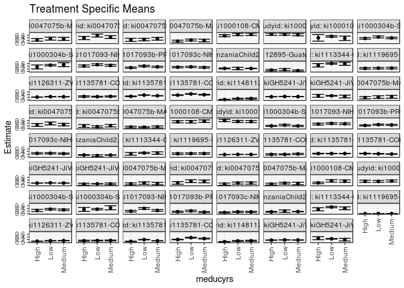

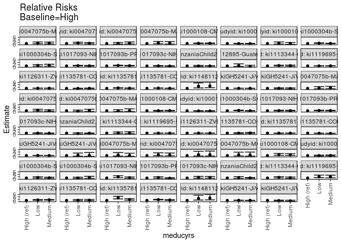

[figure not shown]

[figure not shown]

## Results Table

### Parameter: TSM

| agecat | studyid | country | intervention_level | baseline_level | estimate | ci_lower | ci_upper |
| --- | --- | --- | --- | --- | --- | --- | --- |
| 0-24 months | ki0047075b-MAL-ED | BANGLADESH | High | NA | 0.2456886 | 0.1484927 | 0.3428846 |
| 0-24 months | ki0047075b-MAL-ED | BANGLADESH | Low | NA | 0.3409854 | 0.2302465 | 0.4517243 |
| 0-24 months | ki0047075b-MAL-ED | BANGLADESH | Medium | NA | 0.3186901 | 0.2018470 | 0.4355333 |
| 0-24 months | ki0047075b-MAL-ED | INDIA | High | NA | 0.3884034 | 0.2675125 | 0.5092942 |
| 0-24 months | ki0047075b-MAL-ED | INDIA | Low | NA | 0.5734511 | 0.4607783 | 0.6861240 |
| 0-24 months | ki0047075b-MAL-ED | INDIA | Medium | NA | 0.4556709 | 0.3454353 | 0.5659066 |
| 0-24 months | ki0047075b-MAL-ED | NEPAL | High | NA | 0.2492364 | 0.1299699 | 0.3685029 |
| 0-24 months | ki0047075b-MAL-ED | NEPAL | Low | NA | 0.2724466 | 0.1811978 | 0.3636954 |
| 0-24 months | ki0047075b-MAL-ED | NEPAL | Medium | NA | 0.3277910 | 0.2224216 | 0.4331605 |
| 0-24 months | ki0047075b-MAL-ED | SOUTH AFRICA | High | NA | 0.1501398 | 0.0767456 | 0.2235341 |
| 0-24 months | ki0047075b-MAL-ED | SOUTH AFRICA | Low | NA | 0.2308046 | 0.1606151 | 0.3009940 |
| 0-24 months | ki0047075b-MAL-ED | SOUTH AFRICA | Medium | NA | 0.1964554 | 0.0979774 | 0.2949334 |
| 0-24 months | ki1000108-CMC-V-BCS-2002 | INDIA | High | NA | 0.5569162 | 0.4779420 | 0.6358905 |
| 0-24 months | ki1000108-CMC-V-BCS-2002 | INDIA | Low | NA | 0.6531983 | 0.5626284 | 0.7437682 |
| 0-24 months | ki1000108-CMC-V-BCS-2002 | INDIA | Medium | NA | 0.6627813 | 0.5735434 | 0.7520191 |
| 0-24 months | ki1000108-IRC | INDIA | High | NA | 0.6736979 | 0.5911018 | 0.7562941 |
| 0-24 months | ki1000108-IRC | INDIA | Low | NA | 0.6639211 | 0.5907496 | 0.7370925 |
| 0-24 months | ki1000108-IRC | INDIA | Medium | NA | 0.6302721 | 0.5501351 | 0.7104092 |
| 0-24 months | ki1000109-EE | PAKISTAN | High | NA | 0.4000000 | 0.1517525 | 0.6482475 |
| 0-24 months | ki1000109-EE | PAKISTAN | Low | NA | 0.5075988 | 0.4535051 | 0.5616925 |
| 0-24 months | ki1000109-EE | PAKISTAN | Medium | NA | 0.3636364 | 0.1992922 | 0.5279805 |
| 0-24 months | ki1000304b-SAS-CompFeed | INDIA | High | NA | 0.3593043 | 0.2977896 | 0.4208191 |
| 0-24 months | ki1000304b-SAS-CompFeed | INDIA | Low | NA | 0.4646556 | 0.3881804 | 0.5411307 |
| 0-24 months | ki1000304b-SAS-CompFeed | INDIA | Medium | NA | 0.3911605 | 0.3334439 | 0.4488770 |
| 0-24 months | ki1000304b-SAS-FoodSuppl | INDIA | High | NA | 0.3492141 | 0.1996146 | 0.4988135 |
| 0-24 months | ki1000304b-SAS-FoodSuppl | INDIA | Low | NA | 0.4824828 | 0.4286182 | 0.5363475 |
| 0-24 months | ki1000304b-SAS-FoodSuppl | INDIA | Medium | NA | 0.5169674 | 0.3678481 | 0.6660866 |
| 0-24 months | ki1017093-NIH-Birth | BANGLADESH | High | NA | 0.4209750 | 0.3464492 | 0.4955008 |
| 0-24 months | ki1017093-NIH-Birth | BANGLADESH | Low | NA | 0.5208187 | 0.4561131 | 0.5855244 |
| 0-24 months | ki1017093-NIH-Birth | BANGLADESH | Medium | NA | 0.4687894 | 0.4005489 | 0.5370299 |

[output cut: 159 more lines]

### Parameter: E(Y)

| agecat | studyid | country | intervention_level | baseline_level | estimate | ci_lower | ci_upper |
| --- | --- | --- | --- | --- | --- | --- | --- |
| 0-24 months | ki0047075b-MAL-ED | BANGLADESH | NA | NA | 0.3004695 | 0.2387555 | 0.3621835 |
| 0-24 months | ki0047075b-MAL-ED | INDIA | NA | NA | 0.4727273 | 0.4066048 | 0.5388497 |
| 0-24 months | ki0047075b-MAL-ED | NEPAL | NA | NA | 0.2888889 | 0.2295338 | 0.3482440 |
| 0-24 months | ki0047075b-MAL-ED | SOUTH AFRICA | NA | NA | 0.1955128 | 0.1514355 | 0.2395901 |
| 0-24 months | ki1000108-CMC-V-BCS-2002 | INDIA | NA | NA | 0.6139410 | 0.5644682 | 0.6634139 |
| 0-24 months | ki1000108-IRC | INDIA | NA | NA | 0.6560976 | 0.6100625 | 0.7021326 |
| 0-24 months | ki1000109-EE | PAKISTAN | NA | NA | 0.4907162 | 0.4401862 | 0.5412462 |
| 0-24 months | ki1000304b-SAS-CompFeed | INDIA | NA | NA | 0.4150694 | 0.3581204 | 0.4720184 |
| 0-24 months | ki1000304b-SAS-FoodSuppl | INDIA | NA | NA | 0.4712919 | 0.4233811 | 0.5192026 |
| 0-24 months | ki1017093-NIH-Birth | BANGLADESH | NA | NA | 0.4775641 | 0.4383415 | 0.5167867 |
| 0-24 months | ki1017093b-PROVIDE | BANGLADESH | NA | NA | 0.3514286 | 0.3160364 | 0.3868207 |
| 0-24 months | ki1017093c-NIH-Crypto | BANGLADESH | NA | NA | 0.3311346 | 0.2976093 | 0.3646598 |
| 0-24 months | ki1066203-TanzaniaChild2 | TANZANIA, UNITED REPUBLIC OF | NA | NA | 0.2367980 | 0.2197367 | 0.2538593 |
| 0-24 months | ki1112895-Guatemala BSC | GUATEMALA | NA | NA | 0.1063830 | 0.0703329 | 0.1424331 |
| 0-24 months | ki1113344-GMS-Nepal | NEPAL | NA | NA | 0.5909850 | 0.5515796 | 0.6303903 |
| 0-24 months | ki1119695-PROBIT | BELARUS | NA | NA | 0.2565984 | 0.1993515 | 0.3138454 |
| 0-24 months | ki1126311-ZVITAMBO | ZIMBABWE | NA | NA | 0.2346433 | 0.2276029 | 0.2416837 |
| 0-24 months | ki1135781-COHORTS | GUATEMALA | NA | NA | 0.2564297 | 0.2328823 | 0.2799770 |
| 0-24 months | ki1135781-COHORTS | INDIA | NA | NA | 0.3329911 | 0.3209071 | 0.3450751 |
| 0-24 months | ki1135781-COHORTS | PHILIPPINES | NA | NA | 0.4036125 | 0.3861835 | 0.4210415 |
| 0-24 months | ki1148112-LCNI-5 | MALAWI | NA | NA | 0.0798526 | 0.0612199 | 0.0984853 |
| 0-24 months | kiGH5241-JiVitA-3 | BANGLADESH | NA | NA | 0.2581148 | 0.2516506 | 0.2645791 |
| 0-24 months | kiGH5241-JiVitA-4 | BANGLADESH | NA | NA | 0.3168617 | 0.2936158 | 0.3401077 |
| 0-6 months | ki0047075b-MAL-ED | BANGLADESH | NA | NA | 0.2206573 | 0.1648355 | 0.2764790 |
| 0-6 months | ki0047075b-MAL-ED | INDIA | NA | NA | 0.3136364 | 0.2521871 | 0.3750856 |
| 0-6 months | ki0047075b-MAL-ED | NEPAL | NA | NA | 0.1777778 | 0.1277101 | 0.2278455 |
| 0-6 months | ki0047075b-MAL-ED | SOUTH AFRICA | NA | NA | 0.1025641 | 0.0688457 | 0.1362825 |
| 0-6 months | ki1000108-CMC-V-BCS-2002 | INDIA | NA | NA | 0.5190217 | 0.4679041 | 0.5701394 |
| 0-6 months | ki1000108-IRC | INDIA | NA | NA | 0.5439024 | 0.4956326 | 0.5921723 |
| 0-6 months | ki1000304b-SAS-CompFeed | INDIA | NA | NA | 0.2199336 | 0.1753445 | 0.2645227 |
| 0-6 months | ki1017093-NIH-Birth | BANGLADESH | NA | NA | 0.3569132 | 0.3192325 | 0.3945938 |
| 0-6 months | ki1017093b-PROVIDE | BANGLADESH | NA | NA | 0.2585714 | 0.2261125 | 0.2910304 |
| 0-6 months | ki1017093c-NIH-Crypto | BANGLADESH | NA | NA | 0.2585752 | 0.2273844 | 0.2897660 |
| 0-6 months | ki1066203-TanzaniaChild2 | TANZANIA, UNITED REPUBLIC OF | NA | NA | 0.1395641 | 0.1256566 | 0.1534717 |
| 0-6 months | ki1113344-GMS-Nepal | NEPAL | NA | NA | 0.2954925 | 0.2589234 | 0.3320615 |
| 0-6 months | ki1119695-PROBIT | BELARUS | NA | NA | 0.2497780 | 0.1917926 | 0.3077635 |
| 0-6 months | ki1126311-ZVITAMBO | ZIMBABWE | NA | NA | 0.1809503 | 0.1745333 | 0.1873674 |
| 0-6 months | ki1135781-COHORTS | GUATEMALA | NA | NA | 0.2007612 | 0.1765324 | 0.2249900 |
| 0-6 months | ki1135781-COHORTS | INDIA | NA | NA | 0.2511554 | 0.2398221 | 0.2624886 |
| 0-6 months | ki1135781-COHORTS | PHILIPPINES | NA | NA | 0.2355453 | 0.2204685 | 0.2506222 |
| 0-6 months | kiGH5241-JiVitA-3 | BANGLADESH | NA | NA | 0.1763390 | 0.1707116 | 0.1819665 |
| 0-6 months | kiGH5241-JiVitA-4 | BANGLADESH | NA | NA | 0.1126043 | 0.0962730 | 0.1289355 |
| 6-24 months | ki0047075b-MAL-ED | BANGLADESH | NA | NA | 0.1384615 | 0.0898601 | 0.1870630 |
| 6-24 months | ki0047075b-MAL-ED | INDIA | NA | NA | 0.2657005 | 0.2053824 | 0.3260185 |
| 6-24 months | ki0047075b-MAL-ED | NEPAL | NA | NA | 0.1545455 | 0.1066715 | 0.2024194 |
| 6-24 months | ki0047075b-MAL-ED | SOUTH AFRICA | NA | NA | 0.1389961 | 0.0967835 | 0.1812087 |
| 6-24 months | ki1000108-CMC-V-BCS-2002 | INDIA | NA | NA | 0.2654155 | 0.2205451 | 0.3102860 |
| 6-24 months | ki1000108-IRC | INDIA | NA | NA | 0.3097561 | 0.2649438 | 0.3545684 |
| 6-24 months | ki1000304b-SAS-CompFeed | INDIA | NA | NA | 0.3059755 | 0.2638053 | 0.3481458 |
| 6-24 months | ki1000304b-SAS-FoodSuppl | INDIA | NA | NA | 0.3557214 | 0.3088651 | 0.4025777 |
| 6-24 months | ki1017093-NIH-Birth | BANGLADESH | NA | NA | 0.2939002 | 0.2554778 | 0.3323226 |
| 6-24 months | ki1017093b-PROVIDE | BANGLADESH | NA | NA | 0.1609756 | 0.1319065 | 0.1900447 |
| 6-24 months | ki1017093c-NIH-Crypto | BANGLADESH | NA | NA | 0.1315069 | 0.1069744 | 0.1560393 |
| 6-24 months | ki1066203-TanzaniaChild2 | TANZANIA, UNITED REPUBLIC OF | NA | NA | 0.1606166 | 0.1445647 | 0.1766685 |
| 6-24 months | ki1113344-GMS-Nepal | NEPAL | NA | NA | 0.4735945 | 0.4331684 | 0.5140207 |
| 6-24 months | ki1119695-PROBIT | BELARUS | NA | NA | 0.0100615 | 0.0072668 | 0.0128561 |
| 6-24 months | ki1126311-ZVITAMBO | ZIMBABWE | NA | NA | 0.0940163 | 0.0884807 | 0.0995519 |
| 6-24 months | ki1135781-COHORTS | GUATEMALA | NA | NA | 0.1277129 | 0.1088047 | 0.1466210 |
| 6-24 months | ki1135781-COHORTS | INDIA | NA | NA | 0.1266654 | 0.1178579 | 0.1354730 |
| 6-24 months | ki1135781-COHORTS | PHILIPPINES | NA | NA | 0.2666429 | 0.2502871 | 0.2829988 |
| 6-24 months | ki1148112-LCNI-5 | MALAWI | NA | NA | 0.0772105 | 0.0587369 | 0.0956840 |
| 6-24 months | kiGH5241-JiVitA-3 | BANGLADESH | NA | NA | 0.1638889 | 0.1577625 | 0.1700152 |
| 6-24 months | kiGH5241-JiVitA-4 | BANGLADESH | NA | NA | 0.2529335 | 0.2320005 | 0.2738666 |

### Parameter: RR

| agecat | studyid | country | intervention_level | baseline_level | estimate | ci_lower | ci_upper |
| --- | --- | --- | --- | --- | --- | --- | --- |
| 0-24 months | ki0047075b-MAL-ED | BANGLADESH | High | High | 1.0000000 | 1.0000000 | 1.0000000 |
| 0-24 months | ki0047075b-MAL-ED | BANGLADESH | Low | High | 1.3878762 | 0.8323284 | 2.3142314 |
| 0-24 months | ki0047075b-MAL-ED | BANGLADESH | Medium | High | 1.2971302 | 0.7553349 | 2.2275509 |
| 0-24 months | ki0047075b-MAL-ED | INDIA | High | High | 1.0000000 | 1.0000000 | 1.0000000 |
| 0-24 months | ki0047075b-MAL-ED | INDIA | Low | High | 1.4764319 | 1.0225766 | 2.1317239 |
| 0-24 months | ki0047075b-MAL-ED | INDIA | Medium | High | 1.1731899 | 0.7895945 | 1.7431411 |
| 0-24 months | ki0047075b-MAL-ED | NEPAL | High | High | 1.0000000 | 1.0000000 | 1.0000000 |
| 0-24 months | ki0047075b-MAL-ED | NEPAL | Low | High | 1.0931252 | 0.6109168 | 1.9559501 |
| 0-24 months | ki0047075b-MAL-ED | NEPAL | Medium | High | 1.3151810 | 0.7412956 | 2.3333485 |
| 0-24 months | ki0047075b-MAL-ED | SOUTH AFRICA | High | High | 1.0000000 | 1.0000000 | 1.0000000 |
| 0-24 months | ki0047075b-MAL-ED | SOUTH AFRICA | Low | High | 1.5372639 | 0.8640901 | 2.7348771 |
| 0-24 months | ki0047075b-MAL-ED | SOUTH AFRICA | Medium | High | 1.3084831 | 0.6487367 | 2.6391726 |
| 0-24 months | ki1000108-CMC-V-BCS-2002 | INDIA | High | High | 1.0000000 | 1.0000000 | 1.0000000 |
| 0-24 months | ki1000108-CMC-V-BCS-2002 | INDIA | Low | High | 1.1728842 | 0.9617065 | 1.4304337 |
| 0-24 months | ki1000108-CMC-V-BCS-2002 | INDIA | Medium | High | 1.1900915 | 0.9786921 | 1.4471536 |
| 0-24 months | ki1000108-IRC | INDIA | High | High | 1.0000000 | 1.0000000 | 1.0000000 |
| 0-24 months | ki1000108-IRC | INDIA | Low | High | 0.9854878 | 0.8388659 | 1.1577371 |
| 0-24 months | ki1000108-IRC | INDIA | Medium | High | 0.9355412 | 0.7854962 | 1.1142477 |
| 0-24 months | ki1000109-EE | PAKISTAN | High | High | 1.0000000 | 1.0000000 | 1.0000000 |
| 0-24 months | ki1000109-EE | PAKISTAN | Low | High | 1.2689970 | 0.6760590 | 2.3819715 |
| 0-24 months | ki1000109-EE | PAKISTAN | Medium | High | 0.9090909 | 0.4218738 | 1.9589894 |
| 0-24 months | ki1000304b-SAS-CompFeed | INDIA | High | High | 1.0000000 | 1.0000000 | 1.0000000 |
| 0-24 months | ki1000304b-SAS-CompFeed | INDIA | Low | High | 1.2932089 | 1.0499833 | 1.5927771 |
| 0-24 months | ki1000304b-SAS-CompFeed | INDIA | Medium | High | 1.0886606 | 0.9343653 | 1.2684353 |
| 0-24 months | ki1000304b-SAS-FoodSuppl | INDIA | High | High | 1.0000000 | 1.0000000 | 1.0000000 |
| 0-24 months | ki1000304b-SAS-FoodSuppl | INDIA | Low | High | 1.3816248 | 0.8874161 | 2.1510621 |
| 0-24 months | ki1000304b-SAS-FoodSuppl | INDIA | Medium | High | 1.4803739 | 0.8828142 | 2.4824102 |
| 0-24 months | ki1017093-NIH-Birth | BANGLADESH | High | High | 1.0000000 | 1.0000000 | 1.0000000 |
| 0-24 months | ki1017093-NIH-Birth | BANGLADESH | Low | High | 1.2371726 | 0.9986354 | 1.5326875 |
| 0-24 months | ki1017093-NIH-Birth | BANGLADESH | Medium | High | 1.1135802 | 0.8864827 | 1.3988551 |

[output cut: 159 more lines]

### Parameter: PAR

| agecat | studyid | country | intervention_level | baseline_level | estimate | ci_lower | ci_upper |
| --- | --- | --- | --- | --- | --- | --- | --- |
| 0-24 months | ki0047075b-MAL-ED | BANGLADESH | High | NA | 0.0547809 | -0.0255734 | 0.1351351 |
| 0-24 months | ki0047075b-MAL-ED | INDIA | High | NA | 0.0843239 | -0.0192656 | 0.1879133 |
| 0-24 months | ki0047075b-MAL-ED | NEPAL | High | NA | 0.0396525 | -0.0657923 | 0.1450972 |
| 0-24 months | ki0047075b-MAL-ED | SOUTH AFRICA | High | NA | 0.0453730 | -0.0188630 | 0.1096089 |
| 0-24 months | ki1000108-CMC-V-BCS-2002 | INDIA | High | NA | 0.0570248 | -0.0024673 | 0.1165169 |
| 0-24 months | ki1000108-IRC | INDIA | High | NA | -0.0176003 | -0.0856517 | 0.0504510 |
| 0-24 months | ki1000109-EE | PAKISTAN | High | NA | 0.0907162 | -0.1527507 | 0.3341830 |
| 0-24 months | ki1000304b-SAS-CompFeed | INDIA | High | NA | 0.0557651 | -0.0006686 | 0.1121987 |
| 0-24 months | ki1000304b-SAS-FoodSuppl | INDIA | High | NA | 0.1220778 | -0.0207428 | 0.2648984 |
| 0-24 months | ki1017093-NIH-Birth | BANGLADESH | High | NA | 0.0565891 | -0.0070835 | 0.1202617 |
| 0-24 months | ki1017093b-PROVIDE | BANGLADESH | High | NA | 0.0564332 | 0.0199515 | 0.0929150 |
| 0-24 months | ki1017093c-NIH-Crypto | BANGLADESH | High | NA | -0.0007137 | -0.0402810 | 0.0388536 |
| 0-24 months | ki1066203-TanzaniaChild2 | TANZANIA, UNITED REPUBLIC OF | High | NA | -0.0004476 | -0.0294317 | 0.0285364 |
| 0-24 months | ki1112895-Guatemala BSC | GUATEMALA | High | NA | -0.0037865 | -0.0464720 | 0.0388989 |
| 0-24 months | ki1113344-GMS-Nepal | NEPAL | High | NA | 0.1178923 | -0.0067353 | 0.2425200 |
| 0-24 months | ki1119695-PROBIT | BELARUS | High | NA | 0.0140446 | 0.0018156 | 0.0262735 |
| 0-24 months | ki1126311-ZVITAMBO | ZIMBABWE | High | NA | 0.0128073 | 0.0076387 | 0.0179760 |
| 0-24 months | ki1135781-COHORTS | GUATEMALA | High | NA | -0.0095205 | -0.0515801 | 0.0325391 |
| 0-24 months | ki1135781-COHORTS | INDIA | High | NA | 0.0566038 | 0.0294140 | 0.0837936 |
| 0-24 months | ki1135781-COHORTS | PHILIPPINES | High | NA | 0.0333882 | 0.0137476 | 0.0530287 |
| 0-24 months | ki1148112-LCNI-5 | MALAWI | High | NA | 0.0436960 | 0.0222016 | 0.0651904 |
| 0-24 months | kiGH5241-JiVitA-3 | BANGLADESH | High | NA | 0.0103327 | 0.0024617 | 0.0182036 |
| 0-24 months | kiGH5241-JiVitA-4 | BANGLADESH | High | NA | 0.0053565 | -0.1035756 | 0.1142885 |
| 0-6 months | ki0047075b-MAL-ED | BANGLADESH | High | NA | 0.0439943 | -0.0279564 | 0.1159449 |
| 0-6 months | ki0047075b-MAL-ED | INDIA | High | NA | 0.0480326 | -0.0447472 | 0.1408124 |
| 0-6 months | ki0047075b-MAL-ED | NEPAL | High | NA | -0.0094376 | -0.1054357 | 0.0865604 |
| 0-6 months | ki0047075b-MAL-ED | SOUTH AFRICA | High | NA | -0.0026991 | -0.0539914 | 0.0485933 |
| 0-6 months | ki1000108-CMC-V-BCS-2002 | INDIA | High | NA | 0.0164615 | -0.0438212 | 0.0767441 |
| 0-6 months | ki1000108-IRC | INDIA | High | NA | -0.0550856 | -0.1248313 | 0.0146602 |
| 0-6 months | ki1000304b-SAS-CompFeed | INDIA | High | NA | 0.0249812 | -0.0027199 | 0.0526823 |
| 0-6 months | ki1017093-NIH-Birth | BANGLADESH | High | NA | 0.0276211 | -0.0310976 | 0.0863399 |
| 0-6 months | ki1017093b-PROVIDE | BANGLADESH | High | NA | 0.0299243 | 0.0029494 | 0.0568993 |
| 0-6 months | ki1017093c-NIH-Crypto | BANGLADESH | High | NA | -0.0060639 | -0.0401210 | 0.0279932 |
| 0-6 months | ki1066203-TanzaniaChild2 | TANZANIA, UNITED REPUBLIC OF | High | NA | -0.0069737 | -0.0307331 | 0.0167856 |
| 0-6 months | ki1113344-GMS-Nepal | NEPAL | High | NA | 0.0685364 | -0.0253562 | 0.1624290 |
| 0-6 months | ki1119695-PROBIT | BELARUS | High | NA | 0.0088123 | -0.0041446 | 0.0217693 |
| 0-6 months | ki1126311-ZVITAMBO | ZIMBABWE | High | NA | 0.0046471 | 0.0013425 | 0.0079517 |
| 0-6 months | ki1135781-COHORTS | GUATEMALA | High | NA | 0.0127354 | -0.0336700 | 0.0591407 |
| 0-6 months | ki1135781-COHORTS | INDIA | High | NA | 0.0025189 | -0.0202099 | 0.0252476 |
| 0-6 months | ki1135781-COHORTS | PHILIPPINES | High | NA | -0.0153401 | -0.0295372 | -0.0011431 |
| 0-6 months | kiGH5241-JiVitA-3 | BANGLADESH | High | NA | 0.0097071 | 0.0042488 | 0.0151654 |
| 0-6 months | kiGH5241-JiVitA-4 | BANGLADESH | High | NA | 0.0268900 | -0.0449126 | 0.0986925 |
| 6-24 months | ki0047075b-MAL-ED | BANGLADESH | High | NA | 0.0257855 | -0.0361817 | 0.0877527 |
| 6-24 months | ki0047075b-MAL-ED | INDIA | High | NA | 0.0849958 | -0.0055357 | 0.1755274 |
| 6-24 months | ki0047075b-MAL-ED | NEPAL | High | NA | 0.0583916 | -0.0170578 | 0.1338410 |
| 6-24 months | ki0047075b-MAL-ED | SOUTH AFRICA | High | NA | 0.0444015 | -0.0163828 | 0.1051859 |
| 6-24 months | ki1000108-CMC-V-BCS-2002 | INDIA | High | NA | 0.0795411 | 0.0284937 | 0.1305885 |
| 6-24 months | ki1000108-IRC | INDIA | High | NA | 0.0033291 | -0.0649556 | 0.0716139 |
| 6-24 months | ki1000304b-SAS-CompFeed | INDIA | High | NA | 0.0565575 | -0.0186116 | 0.1317267 |
| 6-24 months | ki1000304b-SAS-FoodSuppl | INDIA | High | NA | 0.0265362 | -0.1165478 | 0.1696203 |
| 6-24 months | ki1017093-NIH-Birth | BANGLADESH | High | NA | 0.0970372 | 0.0407122 | 0.1533623 |
| 6-24 months | ki1017093b-PROVIDE | BANGLADESH | High | NA | 0.0055258 | -0.0329116 | 0.0439633 |
| 6-24 months | ki1017093c-NIH-Crypto | BANGLADESH | High | NA | 0.0299276 | -0.0029488 | 0.0628039 |
| 6-24 months | ki1066203-TanzaniaChild2 | TANZANIA, UNITED REPUBLIC OF | High | NA | 0.0119704 | -0.0149233 | 0.0388640 |
| 6-24 months | ki1113344-GMS-Nepal | NEPAL | High | NA | 0.1359179 | 0.0237834 | 0.2480524 |
| 6-24 months | ki1119695-PROBIT | BELARUS | High | NA | 0.0047308 | 0.0019710 | 0.0074906 |
| 6-24 months | ki1126311-ZVITAMBO | ZIMBABWE | High | NA | 0.0167778 | 0.0112321 | 0.0223234 |
| 6-24 months | ki1135781-COHORTS | GUATEMALA | High | NA | 0.0170346 | -0.0183206 | 0.0523899 |
| 6-24 months | ki1135781-COHORTS | INDIA | High | NA | 0.0659575 | 0.0460541 | 0.0858610 |
| 6-24 months | ki1135781-COHORTS | PHILIPPINES | High | NA | 0.0640544 | 0.0433281 | 0.0847807 |
| 6-24 months | ki1148112-LCNI-5 | MALAWI | High | NA | 0.0412149 | 0.0199369 | 0.0624930 |
| 6-24 months | kiGH5241-JiVitA-3 | BANGLADESH | High | NA | 0.0079069 | -0.0016699 | 0.0174837 |
| 6-24 months | kiGH5241-JiVitA-4 | BANGLADESH | High | NA | -0.0494913 | -0.1642116 | 0.0652290 |

### Parameter: PAF

| agecat | studyid | country | intervention_level | baseline_level | estimate | ci_lower | ci_upper |
| --- | --- | --- | --- | --- | --- | --- | --- |
| 0-24 months | ki0047075b-MAL-ED | BANGLADESH | High | NA | 0.1823176 | -0.1333784 | 0.4100783 |
| 0-24 months | ki0047075b-MAL-ED | INDIA | High | NA | 0.1783774 | -0.0734493 | 0.3711267 |
| 0-24 months | ki0047075b-MAL-ED | NEPAL | High | NA | 0.1372585 | -0.3173267 | 0.4349747 |
| 0-24 months | ki0047075b-MAL-ED | SOUTH AFRICA | High | NA | 0.2320716 | -0.1746705 | 0.4979750 |
| 0-24 months | ki1000108-CMC-V-BCS-2002 | INDIA | High | NA | 0.0928832 | -0.0100574 | 0.1853325 |
| 0-24 months | ki1000108-IRC | INDIA | High | NA | -0.0268258 | -0.1359616 | 0.0718249 |
| 0-24 months | ki1000109-EE | PAKISTAN | High | NA | 0.1848649 | -0.4985851 | 0.5566182 |
| 0-24 months | ki1000304b-SAS-CompFeed | INDIA | High | NA | 0.1343512 | -0.0053075 | 0.2546083 |
| 0-24 months | ki1000304b-SAS-FoodSuppl | INDIA | High | NA | 0.2590280 | -0.1161831 | 0.5081099 |
| 0-24 months | ki1017093-NIH-Birth | BANGLADESH | High | NA | 0.1184953 | -0.0257692 | 0.2424704 |
| 0-24 months | ki1017093b-PROVIDE | BANGLADESH | High | NA | 0.1605823 | 0.0500797 | 0.2582304 |
| 0-24 months | ki1017093c-NIH-Crypto | BANGLADESH | High | NA | -0.0021552 | -0.1290550 | 0.1104817 |
| 0-24 months | ki1066203-TanzaniaChild2 | TANZANIA, UNITED REPUBLIC OF | High | NA | -0.0018904 | -0.1320808 | 0.1133280 |
| 0-24 months | ki1112895-Guatemala BSC | GUATEMALA | High | NA | -0.0355932 | -0.5254587 | 0.2969634 |
| 0-24 months | ki1113344-GMS-Nepal | NEPAL | High | NA | 0.1994845 | -0.0420981 | 0.3850626 |
| 0-24 months | ki1119695-PROBIT | BELARUS | High | NA | 0.0547337 | 0.0029549 | 0.1038234 |
| 0-24 months | ki1126311-ZVITAMBO | ZIMBABWE | High | NA | 0.0545821 | 0.0323529 | 0.0763006 |
| 0-24 months | ki1135781-COHORTS | GUATEMALA | High | NA | -0.0371271 | -0.2148735 | 0.1146136 |
| 0-24 months | ki1135781-COHORTS | INDIA | High | NA | 0.1699859 | 0.0843157 | 0.2476409 |
| 0-24 months | ki1135781-COHORTS | PHILIPPINES | High | NA | 0.0827233 | 0.0327947 | 0.1300744 |
| 0-24 months | ki1148112-LCNI-5 | MALAWI | High | NA | 0.5472081 | 0.2309875 | 0.7333977 |
| 0-24 months | kiGH5241-JiVitA-3 | BANGLADESH | High | NA | 0.0400312 | 0.0090509 | 0.0700431 |
| 0-24 months | kiGH5241-JiVitA-4 | BANGLADESH | High | NA | 0.0169047 | -0.3945611 | 0.3069674 |
| 0-6 months | ki0047075b-MAL-ED | BANGLADESH | High | NA | 0.1993783 | -0.2009484 | 0.4662592 |
| 0-6 months | ki0047075b-MAL-ED | INDIA | High | NA | 0.1531475 | -0.2003522 | 0.4025427 |
| 0-6 months | ki0047075b-MAL-ED | NEPAL | High | NA | -0.0530867 | -0.7574059 | 0.3689610 |
| 0-6 months | ki0047075b-MAL-ED | SOUTH AFRICA | High | NA | -0.0263158 | -0.6706242 | 0.3695027 |
| 0-6 months | ki1000108-CMC-V-BCS-2002 | INDIA | High | NA | 0.0317163 | -0.0917490 | 0.1412190 |
| 0-6 months | ki1000108-IRC | INDIA | High | NA | -0.1012784 | -0.2376658 | 0.0200795 |
| 0-6 months | ki1000304b-SAS-CompFeed | INDIA | High | NA | 0.1135853 | -0.0075799 | 0.2201800 |
| 0-6 months | ki1017093-NIH-Birth | BANGLADESH | High | NA | 0.0773889 | -0.1028720 | 0.2281868 |
| 0-6 months | ki1017093b-PROVIDE | BANGLADESH | High | NA | 0.1157295 | 0.0048904 | 0.2142229 |
| 0-6 months | ki1017093c-NIH-Crypto | BANGLADESH | High | NA | -0.0234512 | -0.1638633 | 0.1000211 |
| 0-6 months | ki1066203-TanzaniaChild2 | TANZANIA, UNITED REPUBLIC OF | High | NA | -0.0499678 | -0.2347294 | 0.1071465 |
| 0-6 months | ki1113344-GMS-Nepal | NEPAL | High | NA | 0.2319395 | -0.1600579 | 0.4914764 |
| 0-6 months | ki1119695-PROBIT | BELARUS | High | NA | 0.0352806 | -0.0187442 | 0.0864404 |
| 0-6 months | ki1126311-ZVITAMBO | ZIMBABWE | High | NA | 0.0256815 | 0.0072686 | 0.0437530 |
| 0-6 months | ki1135781-COHORTS | GUATEMALA | High | NA | 0.0634353 | -0.1983255 | 0.2680174 |
| 0-6 months | ki1135781-COHORTS | INDIA | High | NA | 0.0100291 | -0.0847252 | 0.0965062 |
| 0-6 months | ki1135781-COHORTS | PHILIPPINES | High | NA | -0.0651260 | -0.1270875 | -0.0065708 |
| 0-6 months | kiGH5241-JiVitA-3 | BANGLADESH | High | NA | 0.0550480 | 0.0235786 | 0.0855031 |
| 0-6 months | kiGH5241-JiVitA-4 | BANGLADESH | High | NA | 0.2388005 | -0.7544489 | 0.6697398 |
| 6-24 months | ki0047075b-MAL-ED | BANGLADESH | High | NA | 0.1862285 | -0.4042934 | 0.5284290 |
| 6-24 months | ki0047075b-MAL-ED | INDIA | High | NA | 0.3198934 | -0.1159451 | 0.5855128 |
| 6-24 months | ki0047075b-MAL-ED | NEPAL | High | NA | 0.3778280 | -0.3397954 | 0.7110768 |
| 6-24 months | ki0047075b-MAL-ED | SOUTH AFRICA | High | NA | 0.3194444 | -0.2779704 | 0.6375848 |
| 6-24 months | ki1000108-CMC-V-BCS-2002 | INDIA | High | NA | 0.2996852 | 0.0827864 | 0.4652927 |
| 6-24 months | ki1000108-IRC | INDIA | High | NA | 0.0107476 | -0.2361938 | 0.2083602 |
| 6-24 months | ki1000304b-SAS-CompFeed | INDIA | High | NA | 0.1848433 | -0.1023276 | 0.3972024 |
| 6-24 months | ki1000304b-SAS-FoodSuppl | INDIA | High | NA | 0.0745983 | -0.4293434 | 0.4008660 |
| 6-24 months | ki1017093-NIH-Birth | BANGLADESH | High | NA | 0.3301707 | 0.1122363 | 0.4946051 |
| 6-24 months | ki1017093b-PROVIDE | BANGLADESH | High | NA | 0.0343270 | -0.2360201 | 0.2455428 |
| 6-24 months | ki1017093c-NIH-Crypto | BANGLADESH | High | NA | 0.2275742 | -0.0631156 | 0.4387802 |
| 6-24 months | ki1066203-TanzaniaChild2 | TANZANIA, UNITED REPUBLIC OF | High | NA | 0.0745275 | -0.1088746 | 0.2275959 |
| 6-24 months | ki1113344-GMS-Nepal | NEPAL | High | NA | 0.2869921 | 0.0062729 | 0.4884106 |
| 6-24 months | ki1119695-PROBIT | BELARUS | High | NA | 0.4701884 | 0.1893384 | 0.6537392 |
| 6-24 months | ki1126311-ZVITAMBO | ZIMBABWE | High | NA | 0.1784560 | 0.1182598 | 0.2345427 |
| 6-24 months | ki1135781-COHORTS | GUATEMALA | High | NA | 0.1333823 | -0.1919405 | 0.3699130 |
| 6-24 months | ki1135781-COHORTS | INDIA | High | NA | 0.5207223 | 0.3409793 | 0.6514417 |
| 6-24 months | ki1135781-COHORTS | PHILIPPINES | High | NA | 0.2402253 | 0.1592436 | 0.3134068 |
| 6-24 months | ki1148112-LCNI-5 | MALAWI | High | NA | 0.5338001 | 0.2077863 | 0.7256518 |
| 6-24 months | kiGH5241-JiVitA-3 | BANGLADESH | High | NA | 0.0482455 | -0.0119671 | 0.1048754 |
| 6-24 months | kiGH5241-JiVitA-4 | BANGLADESH | High | NA | -0.1956692 | -0.7488567 | 0.1825375 |